# Lab 01 Report

Group 12

January 28, 2019

## Comparison of Alcohol Users and Non-users

In this exercise, we will attempt to provide an answer to the question, “How do light users of alcohol differ from those who are heavy users of alcohol in terms of their self-reported overall health?” In this document we will:

- load our data
- make a definition of “light users” and “heavy users”
- filter our data to create two new, smaller datasets: a “light users” dataset and a “heavy users” dataset
- combine those two datasets
- prepare a large variety of graphs displaying the distribution of self-reported overall health of both groups
- report the results
- give several possible conclusions based on these results

Our group will compare people who use alcohol to people who do not use alcohol. We will compare the distribution of Non-users, Light Users, Moderate Users, and Heavy Users. Finally, we will illustrate the difference of heavy alcohol users to light alcohol users.

Our central goal is to illustrate the frequency of alcohol use overall as well as illustrate how the severity of alcohol use differs within alcohol users. We also want to determine if heavy users of alcohol are less healthy than light users.

For the purposes of this data, we will define the following terms:

A Current User is a person who has used alcohol in the past 30 days. A Former User is a person who has not used alcohol in the past 30 days. A Non-user is a person who has not used alcohol in their lifetime. A Light User is a person who has drank less than 10 days in the past month. A Moderate User is a person who has drank between 10 and 20 days in the past month. A Heavy User is a person who has drank over 20 days in the past month. Health is a self-reported variable.

## Data

Data is from the National Survey on Drug Use and Health , which is conducted annually by the Substance Abuse and Mental Health Services Administration (SAMHSA), an agency in the U.S. Department of Health and Human Services (DHHS). More information about this survey can be found at [ICPSR’s data archive page](http://www.icpsr.umich.edu/icpsrweb/ICPSR/series/64). The data has been prepared into a .Rdata file, so we can simply load it in the workspace with the `load()` command. At this time, we’ll also load our packages:

```r
library(tidyverse)
library(forcats)
load("36361-0001-Data.rda")
```

Because the data object has an unpleasant name, *da36361.0001*, we make a copy with the name *full_data* and remove the original data object.

```r
full_data <- da36361.0001
remove(da36361.0001)
```

# Definition of “Light User”

```r
light_use_criteria <- 10
```

# Definition of “Heavy User”

We have defined heavy users as those who have drank alcohol more than 20 days within the past month.

```r
heavy_use_criteria <- 20
```

# Data Manipulation

We ar looking for the self-reported overall health of people who are categorized as “heavy,” “light,” “moderate,” or “never” users. Below we have manipulated the data to classify people under these definitions using the variable *alc_user_status*.

```r
full_data <- mutate(full_data, alc_user_status =
                    ifelse(ALCFLAG == "(0) Never used (IRALCRC = 9)", "Never User",
                           ifelse(ALCMON == "(0) Did not use in the past month (IRALCRC = 2-3,0)",
                                  "Former User", "Current User")))
full_data <- mutate(full_data, alc_30day_use = cut(ALCDAYS, c(0, 10, 20, 30),
                                                   c("Light User", "Moderate User", "Heavy User")))

full_data <- mutate(full_data, alc_user_status = ifelse(alc_user_status =="Current User",
                                                        as.character(alc_30day_use), alc_user_status))

full_data <- filter(full_data, !is.na(alc_user_status), !is.na(HEALTH))

full_data <- mutate(full_data, alc_user_status = as.factor(alc_user_status))

full_data <- mutate(full_data, alc_user_status = fct_relevel(alc_user_status,
                                                            "Never User",
                                                            "Light User",
                                                            "Moderate User",
                                                            "Heavy User"))
```

Using these definitions, we can now create two data subgroups: heavy users and light users. Now, we wish to compare the relative health of people who we have defined as heavy users versus those we have defined as light users.

```r
heavy_users <- filter(full_data, ALCDAYS > heavy_use_criteria)
light_users <- filter(full_data, ALCDAYS < light_use_criteria)
```

```r
heavy_users <- select(heavy_users, HEALTH)
light_users <- select(light_users, HEALTH)
```

It may be useful to us to have the data about both groups (heavy and light users) in our data object. To accomplish this, we add a new variable *user_status* to both our data objects. For all observations in *heavy_users* we wish to set the value of this variable to “heavy” For all observations in *light_users* we wish to set the value of this variable to “light” Once we have added this variable to both datasets, we combine them using the **rbind()** function. **rbind()** stands for row bind – it binds or glues two datasets together along by putting one dataset on top of the other.

```r
heavy_users$alc_user_status <- "heavy"
light_users$alc_user_status <- "light"
combined_data <- rbind(heavy_users, light_users)
```

## Graphs

We start our graphical analysis by making a some basic plots showing the self-reported overall health of regular users.

[figure not shown]

```r
ggplot(full_data)+
  geom_bar(aes(x=alc_user_status, fill=HEALTH),position="fill")+
  scale_x_discrete(name="Use of Alcohol",labels=c("Never User",
                            "Former User",
                            "Light Current User\n(10 or fewer days per month)",
                            "Moderate Current User\n(11-20 days per month)",
                            "Heavy Current User\n(more than 20 days per month)"))+
  scale_fill_brewer(palette="RdYlGn",direction=-1,
                    labels=c("Excellent","Very Good","Good","Fair","Poor"),
                    name="Self-Reported \nOverall Health")+
  coord_flip()+labs(y="Proportion",title="Self-Reported Health by Marijuana User Status")+
  theme_classic()
```

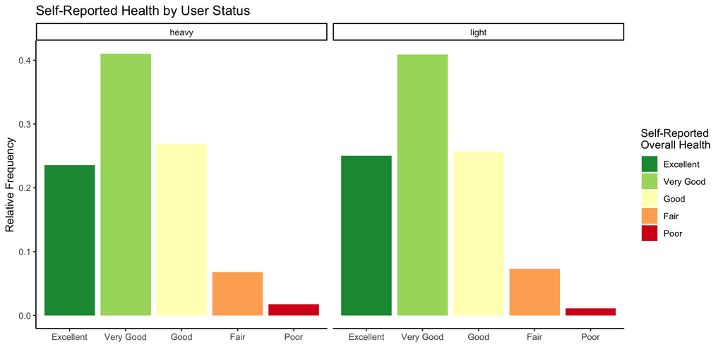

```r
ggplot(combined_data)+
  geom_bar(aes(x=HEALTH, fill=HEALTH, y=(..count..)/tapply(..count..,..PANEL..,sum)[..PANEL..]))+scale_fill_brewer(palette="RdYlGn", direction=-1,labels=c("Excellent", "Very Good", "Good", "Fair", "Poor"), name="Self-Reported \nOverall Health")+
  labs(x="", y="Relative Frequency", title="Self-Reported Health by User Status")+scale_x_discrete(labels=c("Excellent", "Very Good", "Good", "Fair", "Poor"))+facet_wrap("alc_user_status")+theme_classic()
```

Figure 2: Bar graph comparing the number of times a heavy or light user categorized their health as “poor,” “fair,” “good,” “very good,” and “excellent.”

## Pie Chart Comparing Heavy and Light Users

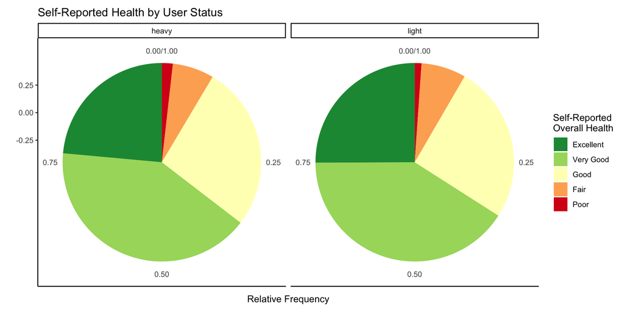

```r
ggplot(combined_data) + geom_bar(aes(x=0, fill=HEALTH, y=..count../tapply(..count..,..PANEL..,sum)[..PANEL..]))+ coord_polar(theta="y") + scale_fill_brewer(palette="RdYlGn", direction =-1, labels=c("Excellent", "Very Good", "Good", "Fair", "Poor"), name="Self-Reported \nOverall Health")+
labs(x="", y="Relative Frequency", title="Self-Reported Health by User Status") +facet_wrap("alc_user_status")+theme_classic()
```

Figure 3: Pie chart comparing percentages of heavy users and light users reporting health on the scale of “poor,” “fair,” “good,” “very good,” and “excellent”

## Stacked Bar Plot Comparison of Heavy and Light Users

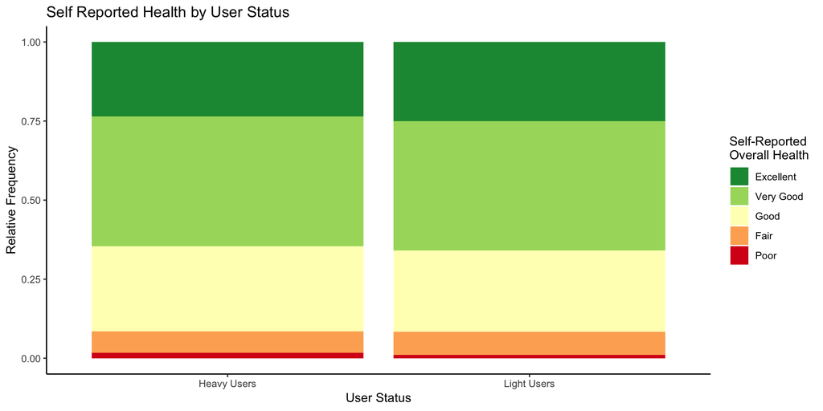

```r
ggplot(combined_data)+geom_bar(aes(x=alc_user_status, fill=HEALTH),position="fill")+scale_fill_brewer(palette="RdYlGn", direction=-1, labels=c("Excellent", "Very Good", "Good", "Fair", "Poor"), name="Self-Reported \nOverall Health") + labs(x="User Status", y="Relative Frequency", title="Self Reported Health by User Status")+scale_x_discrete(labels=c("Heavy Users", "Light Users"))+theme_classic()
```

Figure 4: Stacked bar plot comparing the number of times a heavy or light user categorized their health as “poor,” “fair,” “good,” “very good,” and “excellent.”

# Numerical Verifcation

```r
user_counts <- count(combined_data,alc_user_status)
health_counts <- count(combined_data,alc_user_status,HEALTH)
print(user_counts)
```

```
## # A tibble: 2 x 2
##   alc_user_status     n
##   <chr>           <int>
## 1 heavy            2072
## 2 light           17735
```

```r
print(health_counts,n=nrow(health_counts))
```

```
## # A tibble: 10 x 3
##    alc_user_status HEALTH            n
##    <chr>           <fct>         <int>
##  1 heavy           (1) Excellent   488
##  2 heavy           (2) Very good   850
##  3 heavy           (3) Good        557
##  4 heavy           (4) Fair        140
##  5 heavy           (5) Poor         37
##  6 light           (1) Excellent  4446
##  7 light           (2) Very good  7251
##  8 light           (3) Good       4551
##  9 light           (4) Fair       1291
## 10 light           (5) Poor        196
```

Manually, we see that 488 of 2072 (about 24%) “heavy users” self-reported “excellent” overall health, which is consistent with what our display shows.

# Results

Using side-by-side displays of bar graphs, pie graphs, and stacked bar plot graphs comparing the health of heavy users and light users of alcohol, there does not appear to be much of a difference in the percentages of health reported by heavy and light users. In comparison of health statistics, we deemed it more important to analyze the statistics of reporting on the extremes of the health spectrum: the frequency of reports of “Excellent” health and the frequency of reports of “Poor” health.

Figures 2 through 4 show that overall, heavy users of alcohol and light users of alcohol self-report their health relatively similarly. In other words, heavy users of alcohol and light users of alcohol self-report their health as “fair,” “good,” and “very good” at nearly identical frequencies. For reference, heavy and light users self-report their health as “fair” 7% and 7% of the time, respectively. Heavy and light users self-report their health as “good” 27% and 26% of the time, respectively. Heavy and light users self-report their health as “very good” 41% and 41% of the time, respectively.

However, heavy users and light users self-report their health as “excellent” and “poor” at different levels. Heavy users are more likely to self-report their health as “poor,” while light users are more likely to self-report their health as “excellent.” For reference, heavy and light users self-report their health as “poor” 2% and 1% of the time, respectively. Heavy and light users self-report their health as “excellent” 24% and 25% of the time, respectively.

# Conclusion/Discussion

However, it is important to recognize the limitations of the data. Firstly, it is difficult to confirm the health status of individuals, as self-reported data can be unreliable due to psychological factors affecting people’s perception of their own health. If the health status was not based on self-reporting but instead on quantitative factors, such as the rate of medicine processing in the liver or the number of mental health issues developed since becoming a heavy alcohol drinker, the data could be more reliable. This could help differentiate between how one is “feeling” versus how physically and mentally fit their body is, as a concrete definition of “health” is lacking from the data codebook. Secondly, the amount of reported heavy users (2072 people) is significantly less than the amount of reported light drinkers (17735 people). The analysis would be better if the sample sizes of the light and heavy user categories were either similar or exactly the same.